# Exploratory data analysis of Prosper's loan data

## Preliminary Wrangling

> The loan dataset for Prosper is a large dataset that contains over 100k customer loans information with regards to 81 different variables such as loan creation date, loan amount, credit scores and much more. The aim of this exploration is to assess the data and any relationships that may exist between the different loan attributes.

```python
# import all packages and set plots to be embedded inline
import numpy as np
import pandas as pd
import matplotlib.pyplot as plt
import seaborn as sb

%matplotlib inline
```

```python
#load dataset
df = pd.read_csv('prosper_loan_data.csv')
df.shape
```

```
(113937, 81)
```

```python
#check if data loaded correctly
df.head()
```

|  | ListingKey | ListingNumber | ListingCreationDate | CreditGrade | Term | LoanStatus | ClosedDate | BorrowerAPR | BorrowerRate | LenderYield | ... | LP_ServiceFees | LP_CollectionFees | LP_GrossPrincipalLoss | LP_NetPrincipalLoss | LP_NonPrincipalRecoverypayments | PercentFunded | Recommendations | InvestmentFromFriendsCount | InvestmentFromFriendsAmount | Investors |
| --- | --- | --- | --- | --- | --- | --- | --- | --- | --- | --- | --- | --- | --- | --- | --- | --- | --- | --- | --- | --- | --- |
| 0 | 1021339766868145413AB3B | 193129 | 09:29.3 | C | 36 | Completed | 14/08/2009 00:00 | 0.16516 | 0.1580 | 0.1380 | ... | -133.18 | 0.0 | 0.0 | 0.0 | 0.0 | 1.0 | 0 | 0 | 0.0 | 258 |
| 1 | 10273602499503308B223C1 | 1209647 | 28:07.9 | NaN | 36 | Current | NaN | 0.12016 | 0.0920 | 0.0820 | ... | 0.00 | 0.0 | 0.0 | 0.0 | 0.0 | 1.0 | 0 | 0 | 0.0 | 1 |
| 2 | 0EE9337825851032864889A | 81716 | 00:47.1 | HR | 36 | Completed | 17/12/2009 00:00 | 0.28269 | 0.2750 | 0.2400 | ... | -24.20 | 0.0 | 0.0 | 0.0 | 0.0 | 1.0 | 0 | 0 | 0.0 | 41 |
| 3 | 0EF5356002482715299901A | 658116 | 02:35.0 | NaN | 36 | Current | NaN | 0.12528 | 0.0974 | 0.0874 | ... | -108.01 | 0.0 | 0.0 | 0.0 | 0.0 | 1.0 | 0 | 0 | 0.0 | 158 |
| 4 | 0F023589499656230C5E3E2 | 909464 | 38:39.1 | NaN | 36 | Current | NaN | 0.24614 | 0.2085 | 0.1985 | ... | -60.27 | 0.0 | 0.0 | 0.0 | 0.0 | 1.0 | 0 | 0 | 0.0 | 20 |

5 rows × 81 columns

## 12 attributes chosen to work with

> I focused on 12 attributes for this project that I believe will assist the most in the assessing and analyzing of the data. I would have liked to use credit ratings but credit grade(before 2009) and prosperRating(after july2009) use two different methods that are further complicated by the method used for listing creation date.

```python
#create dataframe with 12 variables to be used
loan_data = df[['ListingKey', 'Term', 'LoanStatus', 'BorrowerAPR', 'BorrowerRate', 'BorrowerState', 'Occupation',
          'StatedMonthlyIncome', 'LoanMonthsSinceOrigination', 'LoanOriginalAmount','LoanOriginationQuarter',
          'MonthlyLoanPayment']]
loan_data= loan_data.copy()
loan_data.shape
```

```
(113937, 12)
```

```python
# check that the 12 attributes loaded succesfully and correctly
loan_data.head()
```

|  | ListingKey | Term | LoanStatus | BorrowerAPR | BorrowerRate | BorrowerState | Occupation | StatedMonthlyIncome | LoanMonthsSinceOrigination | LoanOriginalAmount | LoanOriginationQuarter | MonthlyLoanPayment |
| --- | --- | --- | --- | --- | --- | --- | --- | --- | --- | --- | --- | --- |
| 0 | 1021339766868145413AB3B | 36 | Completed | 0.16516 | 0.1580 | CO | Other | 3083.333333 | 78 | 9425 | Q3 2007 | 330.43 |
| 1 | 10273602499503308B223C1 | 36 | Current | 0.12016 | 0.0920 | CO | Professional | 6125.000000 | 0 | 10000 | Q1 2014 | 318.93 |
| 2 | 0EE9337825851032864889A | 36 | Completed | 0.28269 | 0.2750 | GA | Other | 2083.333333 | 86 | 3001 | Q1 2007 | 123.32 |
| 3 | 0EF5356002482715299901A | 36 | Current | 0.12528 | 0.0974 | GA | Skilled Labor | 2875.000000 | 16 | 10000 | Q4 2012 | 321.45 |
| 4 | 0F023589499656230C5E3E2 | 36 | Current | 0.24614 | 0.2085 | MN | Executive | 9583.333333 | 6 | 15000 | Q3 2013 | 563.97 |

```python
# check the datatypes are correct
loan_data.info()
```

```
<class 'pandas.core.frame.DataFrame'>
RangeIndex: 113937 entries, 0 to 113936
Data columns (total 12 columns):
 #   Column                      Non-Null Count   Dtype
---  ------                      --------------   -----
 0   ListingKey                  113937 non-null  object
 1   Term                        113937 non-null  int64
 2   LoanStatus                  113937 non-null  object
 3   BorrowerAPR                 113912 non-null  float64
 4   BorrowerRate                113937 non-null  float64
 5   BorrowerState               108422 non-null  object
 6   Occupation                  110349 non-null  object
 7   StatedMonthlyIncome         113937 non-null  float64
 8   LoanMonthsSinceOrigination  113937 non-null  int64
 9   LoanOriginalAmount          113937 non-null  int64
 10  LoanOriginationQuarter      113937 non-null  object
 11  MonthlyLoanPayment          113937 non-null  float64
dtypes: float64(4), int64(3), object(5)
memory usage: 10.4+ MB
```

```python
loan_data.describe()
```

|  | Term | BorrowerAPR | BorrowerRate | StatedMonthlyIncome | LoanMonthsSinceOrigination | LoanOriginalAmount | MonthlyLoanPayment |
| --- | --- | --- | --- | --- | --- | --- | --- |
| count | 113937.000000 | 113912.000000 | 113937.000000 | 1.139370e+05 | 113937.000000 | 113937.00000 | 113937.000000 |
| mean | 40.830248 | 0.218828 | 0.192764 | 5.608026e+03 | 31.896882 | 8337.01385 | 272.475783 |
| std | 10.436212 | 0.080364 | 0.074818 | 7.478497e+03 | 29.974184 | 6245.80058 | 192.697812 |
| min | 12.000000 | 0.006530 | 0.000000 | 0.000000e+00 | 0.000000 | 1000.00000 | 0.000000 |
| 25% | 36.000000 | 0.156290 | 0.134000 | 3.200333e+03 | 6.000000 | 4000.00000 | 131.620000 |
| 50% | 36.000000 | 0.209760 | 0.184000 | 4.666667e+03 | 21.000000 | 6500.00000 | 217.740000 |
| 75% | 36.000000 | 0.283810 | 0.250000 | 6.825000e+03 | 65.000000 | 12000.00000 | 371.580000 |
| max | 60.000000 | 0.512290 | 0.497500 | 1.750003e+06 | 100.000000 | 35000.00000 | 2251.510000 |

### missing values

```python
# checking columns that have missing data
loan_data.isnull().sum()
```

```
ListingKey                       0
Term                             0
LoanStatus                       0
BorrowerAPR                     25
BorrowerRate                     0
BorrowerState                 5515
Occupation                    3588
StatedMonthlyIncome              0
LoanMonthsSinceOrigination       0
LoanOriginalAmount               0
LoanOriginationQuarter           0
MonthlyLoanPayment               0
dtype: int64
```

```python
#remove these rows with null values as dataset is large enough for us to remove them and additionally, state and occupation is
#data we can not fill in with mean or median values
loan_data.dropna(inplace=True)

# now check all columns don't have null values
loan_data.info()
```

```
<class 'pandas.core.frame.DataFrame'>
Int64Index: 106221 entries, 0 to 113936
Data columns (total 12 columns):
 #   Column                      Non-Null Count   Dtype
---  ------                      --------------   -----
 0   ListingKey                  106221 non-null  object
 1   Term                        106221 non-null  int64
 2   LoanStatus                  106221 non-null  object
 3   BorrowerAPR                 106221 non-null  float64
 4   BorrowerRate                106221 non-null  float64
 5   BorrowerState               106221 non-null  object
 6   Occupation                  106221 non-null  object
 7   StatedMonthlyIncome         106221 non-null  float64
 8   LoanMonthsSinceOrigination  106221 non-null  int64
 9   LoanOriginalAmount          106221 non-null  int64
 10  LoanOriginationQuarter      106221 non-null  object
 11  MonthlyLoanPayment          106221 non-null  float64
dtypes: float64(4), int64(3), object(5)
memory usage: 10.5+ MB
```

### check very large range of values in StatedMonthlyIncome column

```python
# check for values higher than 500 000
loan_data.query('StatedMonthlyIncome >500000') # two rows have values higher than 500k

#remove these values as they are extreme outliers and will affect the distribution and also make it harder to read graphs

# get index names for the two high incomes
high_income = loan_data[loan_data['StatedMonthlyIncome'] >500000].index

# Delete these row indexes from dataFrame
loan_data.drop(high_income , inplace=True)
```

```python
loan_data=loan_data.reset_index()
loan_data.info()
```

```
<class 'pandas.core.frame.DataFrame'>
RangeIndex: 106219 entries, 0 to 106218
Data columns (total 13 columns):
 #   Column                      Non-Null Count   Dtype
---  ------                      --------------   -----
 0   index                       106219 non-null  int64
 1   ListingKey                  106219 non-null  object
 2   Term                        106219 non-null  int64
 3   LoanStatus                  106219 non-null  object
 4   BorrowerAPR                 106219 non-null  float64
 5   BorrowerRate                106219 non-null  float64
 6   BorrowerState               106219 non-null  object
 7   Occupation                  106219 non-null  object
 8   StatedMonthlyIncome         106219 non-null  float64
 9   LoanMonthsSinceOrigination  106219 non-null  int64
 10  LoanOriginalAmount          106219 non-null  int64
 11  LoanOriginationQuarter      106219 non-null  object
 12  MonthlyLoanPayment          106219 non-null  float64
dtypes: float64(4), int64(4), object(5)
memory usage: 10.5+ MB
```

### Dataset structure

> The final dataset to be used that I have named loan_data has 106 219 rows with 12 feautures(the unique listing key for each loan, loan term,loan status,Annual percentage rate(APR), interest rate, state borrower lives in, occupation, monthly income, months since loan was taken, original loan amount, yearly quarter loan was taken up and monthly loan repayment amount). There are 7 numerical variables and 5 strings variables. I removed rows with null values and also two rows with very large stated monthly income values.

### Main feature of interest in the dataset

> Loan Status is the most interesting feature as it can be used to assess and find out which other features influence the outcome and status of a loan.

### Main features in the dataset that I believe may have the biggest influence on loan status

> I suspect that monthly loan repayment amount may have the biggest impact because the higher amount a borrower repays the less the chances of default and the quicker a loan can be paid up. The original loan amount may also influence the loan status as well as the interest rate and stated monthly income.

## Univariate Exploration

> In this section, I will look at the distributions of each of the variables and to start off with, I will look at the distribution of the main variable of interest, loan status.

```python
loan_data.LoanStatus.value_counts()
```

```
Current                   55271
Completed                 33767
Chargedoff                10833
Defaulted                  4091
Past Due (1-15 days)        798
Past Due (31-60 days)       358
Past Due (61-90 days)       313
Past Due (91-120 days)      304
Past Due (16-30 days)       264
FinalPaymentInProgress      203
Past Due (>120 days)         16
Cancelled                     1
Name: LoanStatus, dtype: int64
```

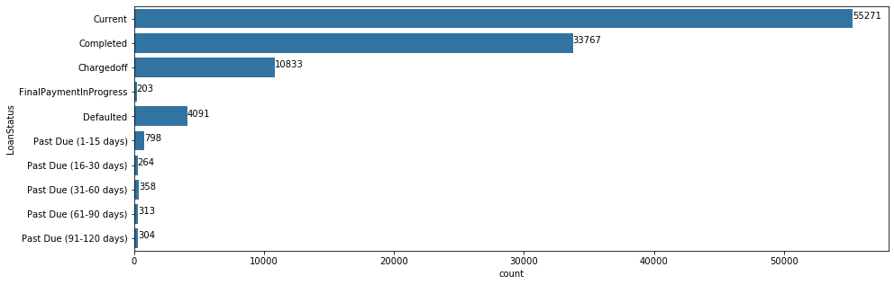

```python
plt.figure(figsize=(15,5))

#order the category differently to the way it is in the dataframe so the past due days are ordered
level_order = ['Current', 'Completed', 'Chargedoff','FinalPaymentInProgress','Defaulted','Past Due (1-15 days)',
               'Past Due (16-30 days)','Past Due (31-60 days)','Past Due (61-90 days)','Past Due (91-120 days)']
ordered_cat = pd.api.types.CategoricalDtype(ordered = True, categories = level_order)
loan_data['LoanStatus'] = loan_data['LoanStatus'].astype(ordered_cat)

# plot the graph and set the bars to one colour
base_color = sb.color_palette()[0]
l_plot = sb.countplot(data = loan_data, y = 'LoanStatus', color = base_color)

# place frequency values of each loan status category in the graph
for p in l_plot.patches:
        percentage = '{:.0f}'.format(p.get_width())
        x = p.get_x() + p.get_width() + 0.02
        y = p.get_y() + p.get_height()/2
        l_plot.annotate(percentage, (x, y))
```

> Current loans are the highest followed by completed loans. The amount of chargedoff loans is notably high showing that Prosper has a high amount of loan amounts that may never be recovered, roughly 10% (10833/106221). Defaulted loans are also seemingly high accounting for about 4% of all loans. All loans that are past due are at a much higher risk of falling either under default or chargedoff loans or should already be considered default or chargedoff.

> Next, I will look at some of the main features that may influence loan status, namely monthly income, original loan amount and monthly payment. I will also look at months since the loan was taken out.

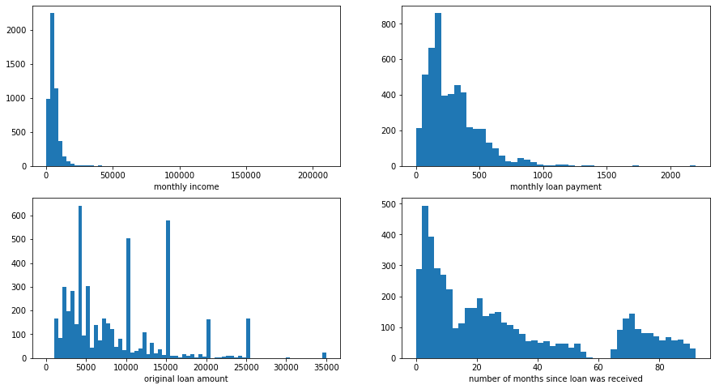

```python
plt.figure(figsize = [15, 8]) # larger figure size for subplots

# create sample of data so plots render faster
samples = np.random.choice(loan_data.shape[0], 5000, replace = False)
loan_sample = loan_data.iloc[samples,:]

# monthly income
plt.subplot(2, 2, 1)
binsize= 3000
bins = np.arange(0, loan_sample['StatedMonthlyIncome'].max()+binsize, binsize)
plt.hist(data=loan_sample, x= 'StatedMonthlyIncome',bins=bins)
plt.xlabel('monthly income')

# monthly repayments
plt.subplot(2, 2, 2)
binsize=50
bins = np.arange(0, loan_sample['MonthlyLoanPayment'].max()+binsize, binsize)
plt.hist(data=loan_sample, x= 'MonthlyLoanPayment',bins=bins)
plt.xlabel('monthly loan payment')

#original loan amount
plt.subplot(2, 2, 3)
binsize=500
bins = np.arange(0, loan_sample['LoanOriginalAmount'].max()+binsize, binsize)
plt.hist(data=loan_sample, x= 'LoanOriginalAmount',bins=bins)
plt.xlabel('original loan amount')

#months since loan received
plt.subplot(2, 2, 4)
binsize=2
bins = np.arange(0, loan_sample['LoanMonthsSinceOrigination'].max()+binsize, binsize)
plt.hist(data=loan_sample, x= 'LoanMonthsSinceOrigination',bins=bins)
plt.xlabel('number of months since loan was received');
```

> The number of months since loan was given graph shows that a high amount of loans are recent and were given out about 12months or less ago. There is also a gap around the 60months(5 year) mark and I assume this is because the longest loan term available is 5 years( which I will look at in following graphs below) and thus anything longer has to be defaulted loans.

> Two of the variables, namely monthly income and monthly repayment are skewed to the right. One cannot use logarithmic transformation of these variables as there are many zero values so a square root transformation can be done, which will be done next.

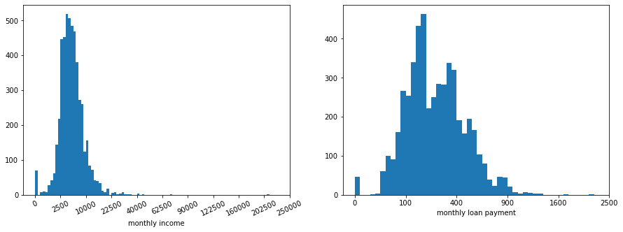

```python
plt.figure(figsize = [15, 5])

# square root transformation
def sqrt_trans(x, inverse = False):
    """ transformation helper function """
    if not inverse:
        return np.sqrt(x)
    else:
        return x ** 2


# monthly income subplot
plt.subplot(1, 2, 1)
bin_edges = np.arange(0, sqrt_trans(loan_sample['StatedMonthlyIncome'].max())+5, 5)
plt.hist(loan_sample['StatedMonthlyIncome'].apply(sqrt_trans), bins = bin_edges)
tick_locs = np.arange(0, sqrt_trans(loan_sample['StatedMonthlyIncome'].max())+50, 50)
plt.xticks(tick_locs, sqrt_trans(tick_locs, inverse = True).astype(int), rotation=25);
plt.xlabel('monthly income');

# monthly repayments subplot
plt.subplot(1, 2, 2)
bin_edges = np.arange(0, sqrt_trans(loan_sample['MonthlyLoanPayment'].max())+1, 1)
plt.hist(loan_sample['MonthlyLoanPayment'].apply(sqrt_trans), bins = bin_edges)
tick_locs = np.arange(0, sqrt_trans(loan_sample['MonthlyLoanPayment'].max())+10, 10)
plt.xticks(tick_locs, sqrt_trans(tick_locs, inverse = True).astype(int));
plt.xlabel('monthly loan payment');
```

> Once the square root transformation has been done, the monthly income variable distribution is unimodal and looks like most customers having an average monthly income of around 5000. The monthly repayment variable seems a little bit bimodal with one peak around the 200 mark and another around 400. Thus doing a slight comparison, it would seem on average with a monthly income of 5000, 200 to 400 of it is for a loan payment.

> Next, we will have a look at the APR and the interest rate.

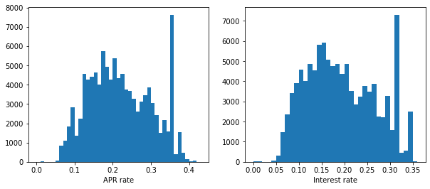

```python
plt.figure(figsize = [10, 4])
#APR rate
plt.subplot(1, 2, 1)
bins=np.arange(0,loan_data.BorrowerAPR.max()+0.01,0.01)
plt.hist(data=loan_data, x= 'BorrowerAPR', bins=bins)
plt.xlabel('APR rate');

#interest rate
plt.subplot(1, 2, 2)
bins=np.arange(0,loan_data.BorrowerRate.max()+0.01,0.01)
plt.hist(data=loan_data, x= 'BorrowerRate', bins=bins)
plt.xlabel('Interest rate');
```

> The APR and borrower rates both lie in the regions between approximately 0.05 and 0.4. The APR rate has one very high peak at about 0.36, which shows that this may be the most common APR rate. interest rate has two peaks, one at about 0.32 and another at about 0.35. The overall distributions of both APR and interest rate seem fairls even.

> Next up, I will look at the loan terms.

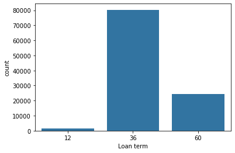

```python
# loan term
sb.countplot(data = loan_data, x='Term', color=base_color)
plt.xlabel('Loan term');
```

> Most loan terms are for 36 months(3years). There seem to be only these three loan terms available. 1 year, 3years and 5 years.

> The following paragraph will have a look at the top 10 Occupations, top 10 states borrowers live in and also the top 10 yearly quarters that borrowers got a loan. I have only looked at the top 10 for each of these variables as they have a large amount of categories within each of them.

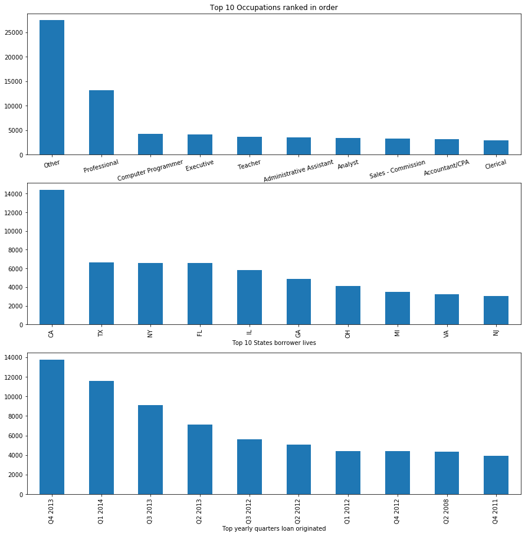

```python
plt.figure(figsize = [15, 15]) # larger figure size for subplots

# plot top 10 occupation types
plt.subplot(3, 1, 1)
loan_data['Occupation'].value_counts().nlargest(10).plot(kind='bar')
plt.xticks(rotation=15)
plt.title('Top 10 Occupations ranked in order');

# Top 10 states
plt.subplot(3, 1, 2)
loan_data['BorrowerState'].value_counts().nlargest(10).plot(kind='bar')
plt.xlabel('Top 10 States borrower lives')

# Top 10 yearly quarter loan was taken
plt.subplot(3, 1, 3)
loan_data['LoanOriginationQuarter'].value_counts().nlargest(10).plot(kind='bar')
plt.xlabel('Top yearly quarters loan originated');
```

> There exists a wide range of occupations that borrowers have with most borrowers stating 'other' as their form of employment and professional and computer programmers being amongst the highest occupations that get loans. It would be interesting to know if this is because they obtain loans much easier because of their professions.

> With regards to borrower states, California has by far the highest amount of borrowers at double or even triple the amount compared to the other states followed by Texas and then New York.

> Q4 2013 had the highest amount of loans taken out. Interestingly enough out of the top 4 quarters, 3 of them were in 2013. Showing that the year 2013 is when Prosper had the largest amount of loans taken by borrowers. Followed by 2012, as all quarters of 2012 are in the top 10.

### Discussion of the distributions of variables of interest with regards to unusual points and transformations.

> The monthly income and monthly loan repayment variables had both very large values and very small values. I used a square root transform because of the zero values that existed I could not use a log transform. Under the transformation the monthly income variable is unimodal with a peak at 5000 and the monthly repayments variable is bimodal with peaks at 200 and 400.

### Adjustments made to some variables

> The categorical variables present, namely Occupation, State and quarter loan was taken have alot of different categories associated with them and as such it makes it very difficult to graph. I decided to then look at each variables top 10 performers in order to be able to have clear graphs and also see which states, occupations or quarters are the most present.

## Bivariate Exploration

> In this section, I will investigate relationships between pairs of variables. I will begin by looking at the pairwise correlations between the numeric variables in the dataset.

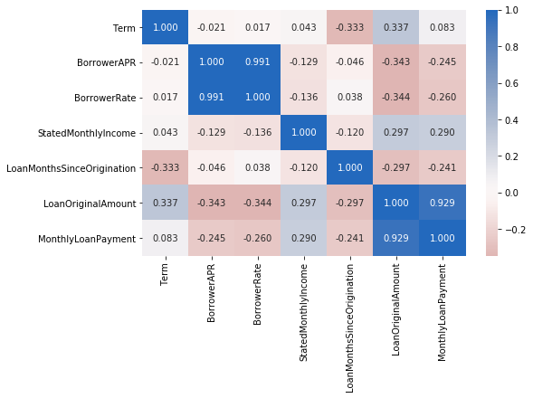

```python
# list of the numeric variables
numeric_vars = ['Term', 'BorrowerAPR', 'BorrowerRate', 'StatedMonthlyIncome', 'LoanMonthsSinceOrigination',
                'LoanOriginalAmount','MonthlyLoanPayment']

# heatmap showing correlations
plt.figure(figsize = [8, 5])
sb.heatmap(loan_data[numeric_vars].corr(), annot = True, fmt = '.3f',
           cmap = 'vlag_r', center = 0)
plt.show()
```

> Not surprisingly there is a high positive correlation between APR and interest rate. Another highly positive correlation exists between the original loan amount and the monthly payment on that loan which makes intuitive sense as very high loan amounts with very low payments would take many more years to pay back if ever. However, there is also a positive relationship between loan term and original loan amount which is quite interesting because an increase in loan amount shouldn't necessarily increase the term but increase the monthly payment.

> Another notable relationship is the somewhat strongly negative one between original loan amount and interest rate. The larger the loan, the lower the interest rate. This is also true for the stated monthly income, the larger your income, the lower your interest rate.

> I will now look at the relationships concerning the main variable of interest, loan status and some of the suggested greatest influencers of loan status.

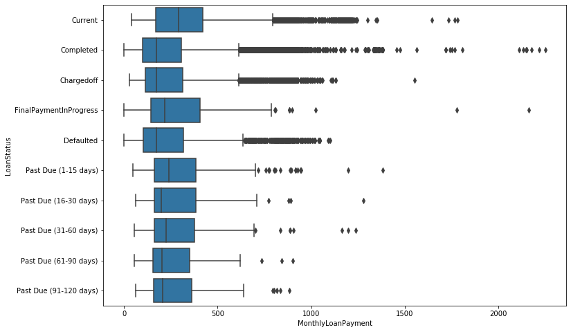

```python
plt.figure(figsize = [12, 8])
sb.boxplot(data = loan_data, y = 'LoanStatus', x = 'MonthlyLoanPayment', color = base_color);
```

> There exists quite a few outliers in the first boxplot. The completed category has the highest large value outliers and this makes intuitive sense because more loans can be completed if much higher payments than normal are being made to them. The final payment in progress category has the longest box and whisker showing that a larger range of monthly payments exist for majority of the customers undergoing their last payment.

> Next, we will look at the relationship between loan status and interest rate.

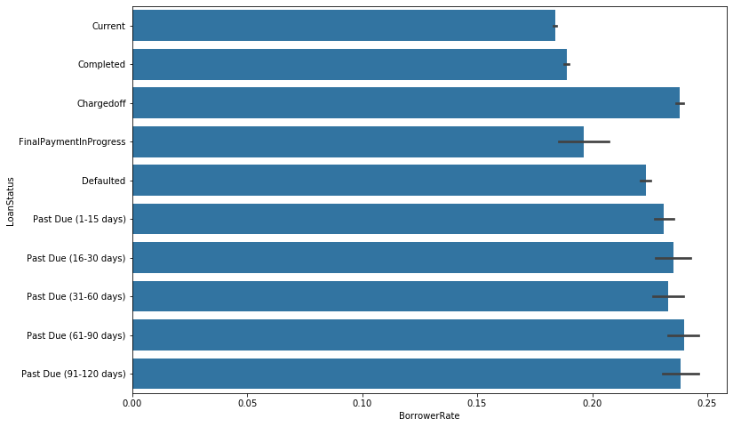

```python
plt.figure(figsize = [12, 8])
sb.barplot(data = loan_data, y = 'LoanStatus', x = 'BorrowerRate', color = base_color);
```

> Interesting to see that all loans that are past due and chargedoff loans have the highest average interest rates. This may be a reason for the loans being harder to pay off or taking longer too. Alternatively, current and completed loans are the ones that had the lowest average APR rates. The longer looking error bars plotted show that past due loans have higher uncertainties in the mean than the shorter error bars associated with current, completed and charged off loans that have lower error bars.

> The next graph will look at the relationship between loan status and original loan amount

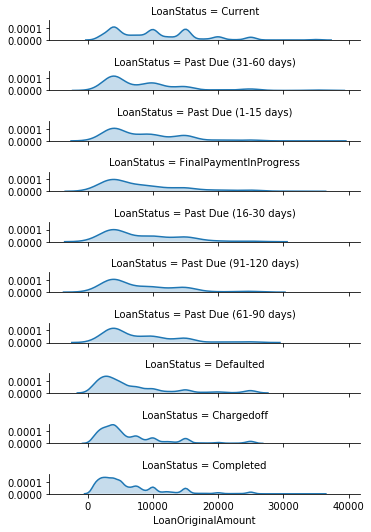

```python
#using kernel density

group_means = loan_data.groupby(['LoanStatus']).mean()
group_order = group_means.sort_values(['LoanOriginalAmount'], ascending = False).index

g = sb.FacetGrid(data = loan_data, row = 'LoanStatus', height = 0.75, aspect = 7,
                 row_order = group_order)
g.map(sb.kdeplot, 'LoanOriginalAmount', shade = True);
```

> As can be seen from the graph above, some of the loan status categories have a few humps, but all of them show that the highest humps are at seemingly lower original loan amounts, more specifically most loans taken out had original value of 4000. Current loan status has quite a few similar sized humps at the 4000, 10000 and about 15000 marks.

> I will look at the relationship between monthly income and loan status next.

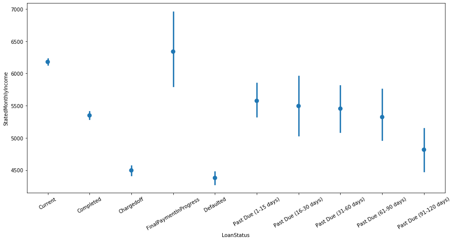

```python
plt.figure(figsize = [15, 7])

sb.pointplot(data = loan_data, x = 'LoanStatus', y = 'StatedMonthlyIncome', linestyles="")
plt.xticks(rotation=30);
```

> The next paragraphs will look at the relationship between some of the other features, occupation, state and loan origination quarter.

```python
# selection of top 5 occupation categories
cat_var_occup = (loan_data['Occupation'] == 'Other') | (loan_data['Occupation'] == 'Professional') | (loan_data['Occupation'] == 'Computer Programmer') | (loan_data['Occupation'] == 'Executive') | (loan_data['Occupation'] == 'Teacher')
loan_cat_occup = loan_data.loc[cat_var_occup,:]

loan_quarter_status_table = pd.crosstab(index=loan_cat_occup["LoanStatus"],
                          columns=loan_cat_occup["Occupation"])

loan_quarter_status_table
```

| Occupation LoanStatus | Computer Programmer | Executive | Other | Professional | Teacher |
| --- | --- | --- | --- | --- | --- |
| Current | 1907 | 2442 | 13919 | 6841 | 2029 |
| Completed | 1874 | 1208 | 8542 | 4443 | 1058 |
| Chargedoff | 290 | 336 | 3209 | 1129 | 340 |
| FinalPaymentInProgress | 10 | 9 | 46 | 29 | 6 |
| Defaulted | 95 | 123 | 1173 | 437 | 140 |
| Past Due (1-15 days) | 23 | 26 | 215 | 97 | 28 |
| Past Due (16-30 days) | 9 | 11 | 83 | 31 | 9 |
| Past Due (31-60 days) | 15 | 15 | 100 | 42 | 13 |
| Past Due (61-90 days) | 14 | 15 | 90 | 33 | 12 |
| Past Due (91-120 days) | 4 | 4 | 100 | 39 | 13 |

> In this table, it is clear that the occupation with the highest amount of completed and current loans is the 'other' occupation, however it is impossible to tell what is included in this category. Thus the next best occupation with high current and completed loans are professionals. Overall, it seems that for all occupations, past due and defaulted loans are much smaller in numbers compared to current and completed loans.

> The next paragraph will look at relationship between loan origination quarter and borrower state.

```python
# create a new column for sorting loan origination quarters
loan_data['Loan_Quarter'] = loan_data.LoanOriginationQuarter.str[-4:]+"-"+ loan_data.LoanOriginationQuarter.str[0:2]
loan_data['Loan_Quarter'].value_counts()
```

```
2013-Q4    13775
2014-Q1    11578
2013-Q3     9116
2013-Q2     7099
2012-Q3     5632
2012-Q2     5061
2012-Q1     4434
2012-Q4     4425
2008-Q2     4344
2011-Q4     3913
2013-Q1     3615
2008-Q3     3602
2011-Q3     3093
2008-Q1     3043
2007-Q4     2485
2011-Q2     2478
2007-Q2     2435
2007-Q3     2380
2011-Q1     1744
2007-Q1     1672
2010-Q4     1600
2010-Q2     1539
2009-Q4     1449
2010-Q3     1270
2010-Q1     1243
2006-Q4     1214
2006-Q3      850
2009-Q3      585
2008-Q4      532
2009-Q2       13
Name: Loan_Quarter, dtype: int64
```

```python
# create new dataframe that contains top 5 borrower states
loan_data_top5_states = pd.DataFrame(loan_data.BorrowerState.value_counts().head(5))
loan_data_top5_states = loan_data_top5_states.reset_index()
loan_data_top5_states.rename(columns={"index":"BorrowerState","BorrowerState":"TotalCount"}, inplace=True)
loan_data_top5_states
```

|  | BorrowerState | TotalCount |
| --- | --- | --- |
| 0 | CA | 14405 |
| 1 | TX | 6617 |
| 2 | NY | 6591 |
| 3 | FL | 6583 |
| 4 | IL | 5840 |

```python
#create dataframe with top5 states and the originating quarter they were taken up
loan_data2 = pd.DataFrame(loan_data.groupby(['BorrowerState', 'Loan_Quarter']).count()['ListingKey'])
loan_data2 = loan_data2.reset_index()
loan_data2.rename(columns={"ListingKey":"QuarterCount"}, inplace=True)
#merge with top5 states
loan_data2 = pd.merge(loan_data2,loan_data_top5_states, how='inner', on=['BorrowerState'])
loan_data2.sort_values(by='Loan_Quarter', ascending=True, inplace=True)
loan_data2
```

|  | BorrowerState | Loan_Quarter | QuarterCount | TotalCount |
| --- | --- | --- | --- | --- |
| 0 | CA | 2006-Q3 | 138 | 14405 |
| 117 | TX | 2006-Q3 | 152 | 6617 |
| 29 | FL | 2006-Q3 | 43 | 6583 |
| 88 | NY | 2006-Q3 | 40 | 6591 |
| 58 | IL | 2006-Q3 | 62 | 5840 |
| ... | ... | ... | ... | ... |
| 57 | FL | 2014-Q1 | 698 | 6583 |
| 28 | CA | 2014-Q1 | 1535 | 14405 |
| 87 | IL | 2014-Q1 | 527 | 5840 |
| 116 | NY | 2014-Q1 | 810 | 6591 |
| 145 | TX | 2014-Q1 | 846 | 6617 |

146 rows × 4 columns

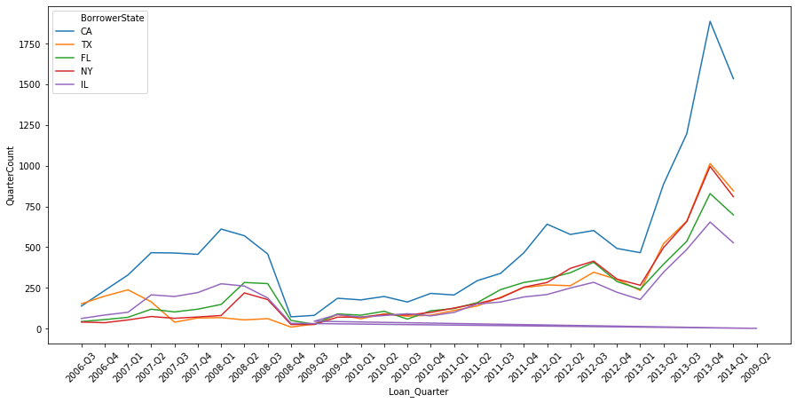

```python
#graph top 5states vs. loan origination quarter
plt.figure(figsize = [15, 7])
sb.lineplot(data=loan_data2, x='Loan_Quarter', y='QuarterCount', hue='BorrowerState')
plt.xticks(rotation=45);
```

### Relationships between the other features (not the main feature(s) of interest)

> A relationship between loan status and occupation does seem to exist to some extent but with the major occupation category of 'other' being the most significant it is difficult to really conclude to a relationship. The relationship between state and origination quarter shows that the state of California has overtime taken up the most loans.

## Multivariate Exploration

In the previous section, we saw the relationship between two variables and in this section I would like to investigate the relationships between these variables when a third significant influencing variable is added to them.

I will begin by taking a look at the relationship between loan original amount and monthly loan payment we saw before and see how the relationship works when we compare it with the main feature, loan status.

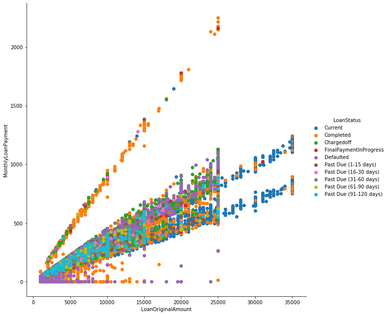

```python
g = sb.FacetGrid(data = loan_data, hue = 'LoanStatus', height = 9)
g.map(plt.scatter, 'LoanOriginalAmount', 'MonthlyLoanPayment')
g.add_legend();
```

> The relationship between interest rate, original amount and monthly payment will be looked at next.

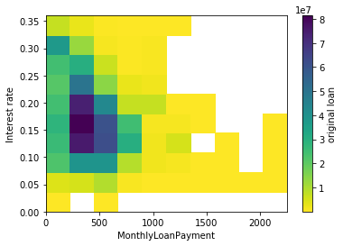

```python
plt.hist2d(data = loan_data, x = 'MonthlyLoanPayment', y = 'BorrowerRate', weights = 'LoanOriginalAmount',
            cmap = 'viridis_r', cmin = 0.5);
plt.xlabel('MonthlyLoanPayment')
plt.ylabel('Interest rate');
plt.colorbar(label = 'original loan');
```

> We will look at the relationship between original amount, status and term next

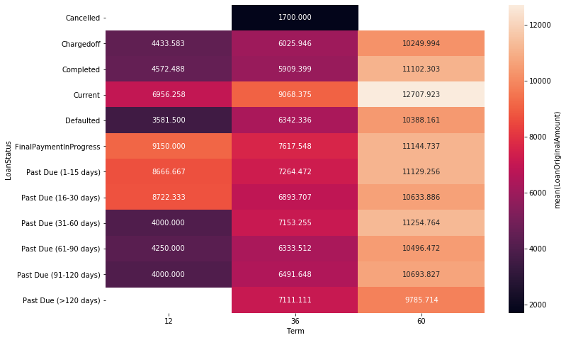

```python
plt.figure(figsize = [12, 8])
cat_means = df.groupby(['Term', 'LoanStatus']).mean()['LoanOriginalAmount']
cat_means = cat_means.reset_index(name = 'LoanOriginalAmount')
cat_means = cat_means.pivot(index = 'LoanStatus', columns = 'Term',
                            values = 'LoanOriginalAmount')
sb.heatmap(cat_means, annot = True, fmt = '.3f',
           cbar_kws = {'label' : 'mean(LoanOriginalAmount)'});
```

> This heatmap shows us the positive relationship that was seen earlier between loan original amount and loan term. The higher the original loan amount, the lighter the colour and the higher the term. adding loan status to the mix shows that there does not really seem to be an effect for 36 and 60 month terms as regardless of loan status, lower terms still have the lower original loan amounts.However for 12 month terms the range is very vast and past due loans between 1 - 30 days had very high original loan amounts. 12 month loan terms had the lowest average original loan sizes. However, the lowest average loan size was of 36 month term and of cancelled status. This is perhaps quite interesting as it would be more convincing to assume that lower original loan amounts should be easier or much faster to pay off. The 60 month term column is associated with the highest average loan amounts, with highest average original amount having current status.

> The relationship between interest rate, loan status and monthly loan payment will be looked at next.

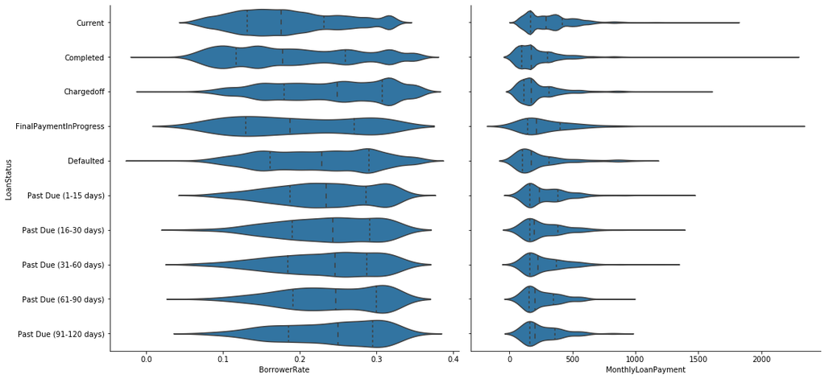

```python
g = sb.PairGrid(data = loan_data, x_vars = ['BorrowerRate', 'MonthlyLoanPayment'], y_vars = ['LoanStatus'], height=7)
g.map(sb.violinplot, inner='quartile');
```

> Lastly, the relationship between loan status, interest rate and original loan amount will be looked at.

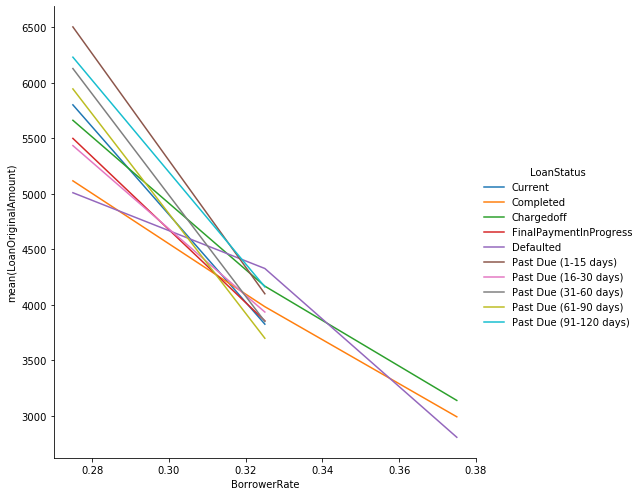

```python
#create function for frequency polygons for levels of loan status
def mean_poly(x, y, bins = 10, **kwargs):
    """ Custom adapted line plot code. """
    # set bin edges if none or int specified
    if type(bins) == int:
        bins = np.linspace(x.min(), x.max(), bins+1)
    bin_centers = (bin_edges[1:] + bin_edges[:-1]) / 2

    # compute counts
    data_bins = pd.cut(x, bins, right = False,
                       include_lowest = True)
    means = y.groupby(data_bins).mean()

    # create plot
    plt.errorbar(x = bin_centers, y = means, **kwargs)

bin_edges = np.arange(0.25, loan_data['BorrowerRate'].max()+0.05, 0.05)
g = sb.FacetGrid(data = loan_data, hue = 'LoanStatus', height = 7)
g.map(mean_poly, "BorrowerRate", "LoanOriginalAmount", bins = bin_edges)
g.set_ylabels('mean(LoanOriginalAmount)')
g.add_legend();
```

> The negative relationship between interest rate and average original loan amount seen here was also seen earlier and we can see here that it is negative for all loan status categories. Completed, Chargedoff and defaulted loans have interest rates that are higher than 0.33 with the other loan status categories not going beyond 0.33. These three also have less steeper slopes which means that the lower the original loan amounts are, the less rate at which the interest rates increases compared to the rest of the categories.

### Interesting and/or surprising interactions between features

> There exists some borrowers with very low monthly payments of around USD200 and average original loan amounts but still have abnormally high interest rates near the maximum of about 0.35.